# RNA velocity with scVelo (mouse pancreas, E15.5) — Corrected & Annotated Edition

## 2. Environment and data

### 2.1 Environment

No conda environment on the cluster carries scVelo, and retrofitting it into the shared scRNA-seq environment (scanpy 1.10.3 / anndata 0.10.9) would have dragged anndata and numba sideways for every other module. A separate environment pinned to the teacher’s own `Session Info` was built instead:

| package | version | why this one |
| --- | --- | --- |
| python | 3.11.18 | teacher’s notebook reports 3.11 |
| scvelo | 0.3.4 | exactly what `pip install scvelo --upgrade` resolves today, and what the teacher ran |
| scanpy | 1.10.4 | teacher’s version; scVelo 0.3.4 is not tested against 1.11 |
| anndata | 0.11.4 | required by scanpy 1.10.4 |
| numpy / scipy / pandas | 1.26.4 / 1.12.0 / 2.2.0 | teacher’s versions; numba 0.60 caps numpy at 1.26 |
| matplotlib | 3.8.2 | teacher’s version — panel geometry depends on it |
| igraph / leidenalg | 0.11.6 / 0.10.2 | not used by this notebook, kept for parity with lesson 5 |
| numba / h5py | 0.60.0 / 3.12.1 | scVelo’s JIT kernels and h5ad I/O |

Building it:

```
conda create -y -n velo python=3.11
conda activate velo
pip install "scvelo==0.3.4" "scanpy==1.10.4" "anndata==0.11.4" \
            "numpy==1.26.4" "scipy==1.12.0" "pandas==2.2.0" \
            "matplotlib==3.8.2" "numba==0.60.0" "h5py==3.12.1" \
            "igraph==0.11.6" "leidenalg==0.10.2"
```

Two pieces of console noise come with this environment and are **not** errors. Importing scVelo pulls in TensorFlow (for a module this notebook never touches), which prints oneDNN/CUDA banners (“Could not find cuda drivers”, “TF-TRT Warning”) even on a CPU-only node. And every `n_jobs>1` call ends with a loky pool shutdown that prints `SystemExit: 0` followed by `OSError: [Errno 16] Device or resource busy: '.nfs00000000...'` — the pool’s temp directory cannot be removed because NFS still holds it. Both appear in the as-written console log in `results/09_run_logs/aswritten_console.txt`; both are harmless (VELO-13).

### 2.2 Input data

`data/Pancreas/endocrinogenesis_day15.h5ad`, 52 MB, from the course share. It is element-for-element identical to what `scv.datasets.pancreas()` downloads, so staging it under `<run>/data/Pancreas/endocrinogenesis_day15.h5ad` and pointing `scv.settings.datasetdir` at `<run>` lets the tutorial’s own line run unchanged and offline:

```python
import scvelo as scv
scv.settings.datasetdir = "<run>"      # the only line added to the tutorial's cell
adata = scv.datasets.pancreas()        # day 15, Ngn3-Venus reporter, E15.5
```

The object is 3,696 cells × 27,998 genes with `layers['spliced']` (9,298,890 non-zeros) and `layers['unspliced']` (3,156,504 non-zeros) from velocyto-style intron/exon counting, `X` as raw counts, `obs['clusters']` with eight annotated populations, `obs['clusters_coarse']` with three, the shipped `S_score`/`G2M_score`, a 50-component `X_pca`, a two-dimensional `X_umap` fitted with k=15 neighbours, and `var['highly_variable_genes']` — the legacy flag of VELO-07.

Cluster sizes, because every velocity statement in this document is conditioned on them:

| cluster | cells | cluster | cells |
| --- | --- | --- | --- |
| Ductal | 916 | Alpha | 481 |
| Ngn3 high EP | 642 | Ngn3 low EP | 262 |
| Pre-endocrine | 592 | Epsilon | 142 |
| Beta | 591 | Delta | 70 |

### 2.3 Run layout

Three scripts, one comparison tool, and a figure-capture harness live in `results/scripts/`:

- `scVelo_py_cells_aswritten.py` — the 29 code cells copied line for line, in order, with PyPlot’s `show` intercepted so that each `scv.pl.*` call is written to `figures/` under the name of the tutorial’s cell. That is the as-written evidence base; it is never edited again.
- `scVelo_py_cells_corrected.py` — the corrected pass (§15): same object, same parameter values unless the issue list says otherwise, plus what the tutorial omits, with tables dumped per step.
- `scVelo_audit_run.py` — an independent audit that reads an `.h5ad` back and re-derives the numbers from the stored object rather than from the run’s own variables (proportions, per-cell speeds, phase-portrait statistics, rankings, cycle scores). Run against both the as-written and the corrected object, so “what changed” cannot be an artefact of the script that changed it.
- `compare_figs_velo.py` — normalises two PNGs to a common canvas, computes structural correlation and ink IoU, and records canvas sizes and colour profiles into a TSV.
- `make_doc_figures.py` — builds the comparison stacks and the two derived charts used below.

### 2.4 Output layout in this repository

```
results/
├── 01_preprocess/        proportions figure + the two audit tables of the input itself
├── 02_velocity/          stream/arrow figures, per-cell velocity, velocity-graph statistics
├── 03_phase_portraits/   the three phase-portrait panels + per-gene phase statistics
├── 04_gene_dynamics/     the two gene panels + the velocity-gene ranking
├── 05_cellcycle/         the two cell-cycle figures + cycle scores and phase markers
├── 06_corrected/         13 corrected figures + the corrected-pass tables (dynamical model,
│                         latent time, sensitivity sweeps, ranking side-by-side)
├── 07_figure_comparison/ the two machine-readable comparison TSVs
├── 09_run_logs/          three console captures (as-written, corrected, both audits)
└── scripts/              the five scripts above
```

## 3. The as-written run: what the tutorial actually produces

### 3.1 The seven steps and their cost

The 29 code cells reduce to seven operations, each with a measured wall time on one node (the as-written run uses no parallelism at all, exactly as the notebook does):

| step | call | time | what it produced |
| --- | --- | --- | --- |
| 0 | `scv.datasets.pancreas()` | 1 s | 3,696 × 27,998 object, 9.3 M spliced / 3.2 M unspliced non-zeros |
| 1a | `scv.pp.filter_and_normalize(min_shared_counts=20)` | 4 s | “Filtered out 20801 genes that are detected 20 counts (shared)”; 7,197 genes |
| 1b | `sc.pp.log1p` | <1 s | `X` logarithmic (max 7.31); layers untouched |
| 1c | `sc.pp.highly_variable_genes(2000, flavor="seurat", subset=True)` | 2 s | 2,000 genes, same order |
| 1d | `scv.pp.moments(n_pcs=30, n_neighbors=30)` | 7 s | `Ms`/`Mu` smoothed layers; neighbour graph rebuilt (VELO-04) |
| 2 | `scv.tl.velocity()` + `velocity_graph()` | 1 s + 9 s | velocity layer over 1,038 genes; Markov graph with 593,854 non-zeros |
| 3–6 | 11 `scv.pl.*` calls + ranking + cell cycle | 4 s | 11 PNGs, inner ranking tables discarded |
| 7 | (nothing) | — | **no file written** (VELO-11) |

Total 42.6 s on one core. The tutorial’s own `Session Info` reports comparable timings, which is the first hint that the teacher ran the same code on the same machine class.

### 3.3 Figure fidelity against the eleven reference PNGs

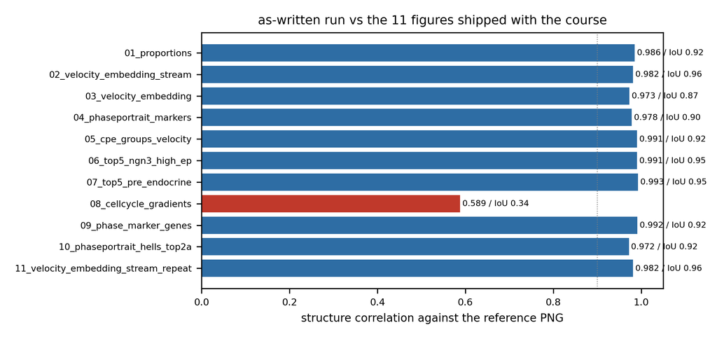

Figure 1 — Structural correlation between the as-written run and each of the 11 reference PNGs shipped with the course. Ten panels land at 0.97–0.99; `08_cellcycle_gradients` is the single outlier at 0.59.

Ten of eleven at ≥0.97 is the strongest possible evidence that the pipeline is deterministic and that the run is faithful — it is also why the eleventh panel is worth a paragraph. Its canvas (1205 × 648) is *identical* to the reference, the legend text is pixel-identical, marker ink is 12% of the panel against our 14%, and the RGB agreement with our figure is 0.78 (0.76 against the variant that keeps the shipped scores). So the discrepancy is not data, not canvas size and not the score version: the colour mapping inside the two marker clouds differs, which means that one PNG was drawn by a different scVelo build than the other ten.

The canvas sizes are themselves informative, because they reveal what the export is:

| reference panels | reference px | our px | ratio | implied dpi |
| --- | --- | --- | --- | --- |
| 01, 02, 08, 11 | 1415×475, 977×690, 1205×648, 977×690 | same | 1.00 | 80 |
| 03 | 1171×828 | 975×690 | 1.20 | 96 |
| 04, 05, 06, 07, 09, 10 | 1644×445 … 1651×628 | 2056×557 … 2065×787 | 0.80 | 64 |

Three dpi settings in one “run” means the eleven PNGs were collected from at least three execution sessions with different `scv.set_figure_params(dpi=...)` — VELO-15. It matters for how the fidelity numbers above should be read: they are computed after normalising each pair to a common canvas, so the correlation measures content, not dpi.

### 3.4 The bottom line

The velocity field this notebook produces is correct and reproducible; the model behind it is not the one the slides teach, and the inputs to that field are chosen by five unexplained defaults. The rest of this document separates those three claims: what the field shows (§11), what the model assumes and what happens when the other model is run (§10, §12), and how much the defaults matter (§14).

## 4. Theory I — why expression is stable, and what an attractor has to do with a cell

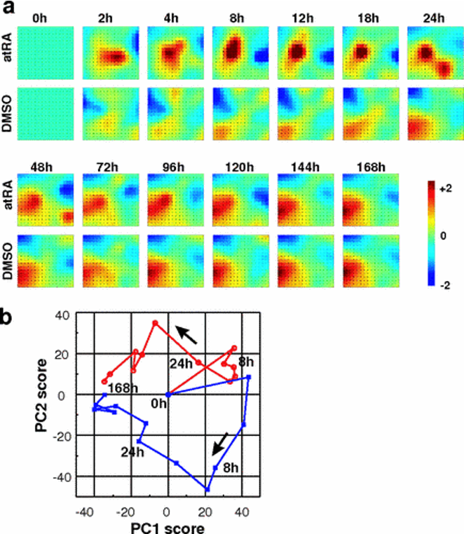

Figure 2 — Expression programmes as attractors. `a`: HL60 differentiation under atRA (top rows) versus DMSO (bottom rows), 0 h to 168 h, density of cells in PC1–PC2 at each time point. `b`: the same data as a trajectory, with the instantaneous velocity drawn as arrows. From Sui et al., 2005.

The second figure converts that claim into a mechanism, using the EGF stimulation time course of MCF10A cells (La Manno et al., 2018, Fig. 1): exon and intron probes separated on the array, so the same gene gives a mature-mRNA signal and a pre-mRNA signal.

[figure not shown]

Figure 3 — The measurement that makes velocity possible. Intronic (pre-mRNA) and exonic (mature) probes for the same gene respond on different time scales; the fitted curves are the model’s α(t), β/γ and γ. Pre-mRNA half-lives are 2–3 min, mature-mRNA half-lives 18–790 min. From La Manno et al., 2018.

## 5. Theory II — the splicing ODE, and the steady-state shortcut

The notebook then writes the two-compartment model down and derives three estimators from it. The model is a chain of two first-order reactions, with the number of reads counted in each compartment:

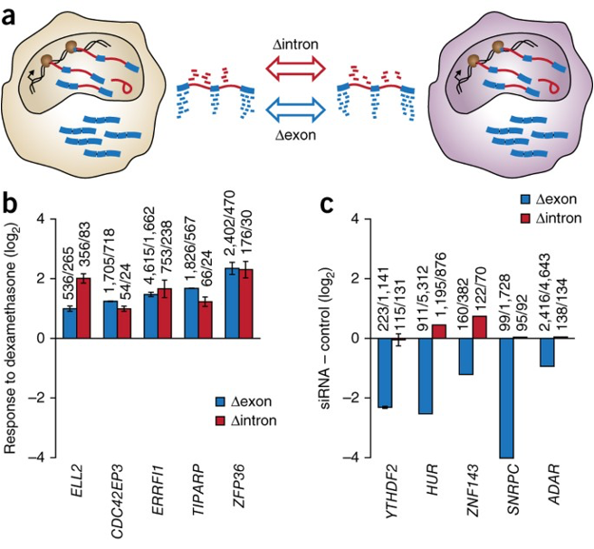

Figure 4 — Intron retention as a measurement. `a`: exon and intron reads from the same cells. `b`: glucocorticoid response measured by exonic (blue) versus intronic (red) signal — same direction, different amplitude. `c`: knockdown effects where the two disagree. The point: the two channels are not redundant.

With α the transcription rate, β the splicing rate and γ the degradation rate, the model is

```
du/dt = α(t) − β(t)·u(t)          u = unspliced (pre-mRNA)
ds/dt = β(t)·u(t) − γ(t)·s(t)     s = spliced (mature mRNA)
```

and since only the *product* βu is identifiable from unlabelled data, scVelo normalises the splicing rate to β = 1 and keeps everything relative (that normalisation is exactly why velocity has units of “unspliced per spliced” and never of time):

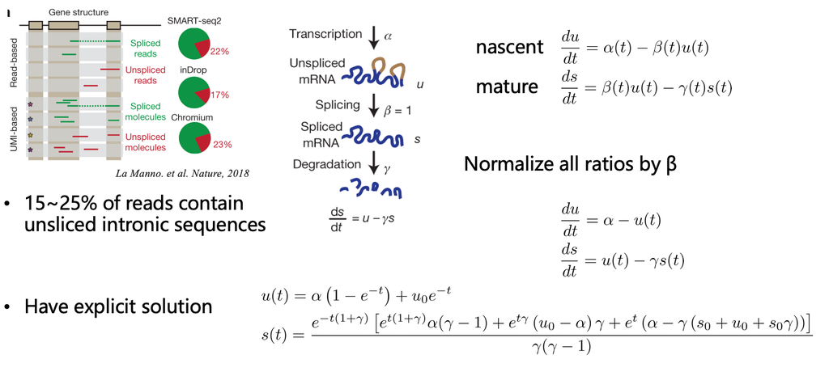

Figure 5 — The model, the normalisation and the closed form. 15–25% of reads in a typical 10x library carry intronic sequence; setting β = 1 renders the system in relative units; the explicit solutions u(t) and s(t) are what the dynamical model fits.

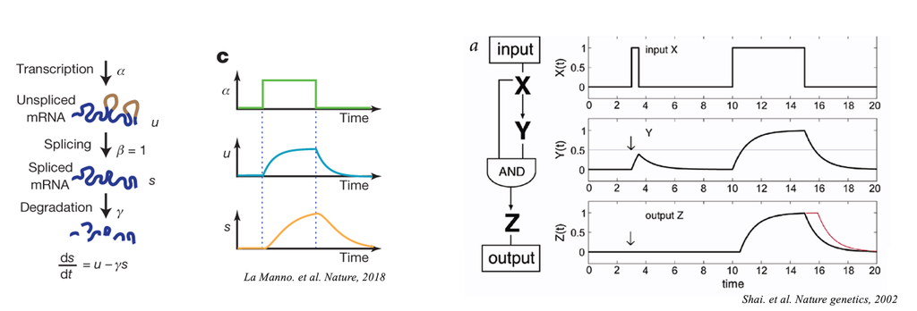

Figure 6 — What a pulse of transcription looks like in the (s, u) plane. A short input raises u almost instantly and s slowly; a long input lets both reach the steady state; the *sign* of u − s is what says “rising” or “falling”. From La Manno et al., 2018.

Three estimators follow from those equations, and the notebook presents all three in one slide. The first is the *steady-state* model, which assumes α and γ are constant and the cell sits near u = γs; velocity is then the residual from that line, v = u − γs, and γ is estimated by regressing u on s through the origin. The second and third relax one assumption each — constant velocity (ds/dt = v) or constant unspliced pool (u = u₀) — and both remain linear in the parameters.

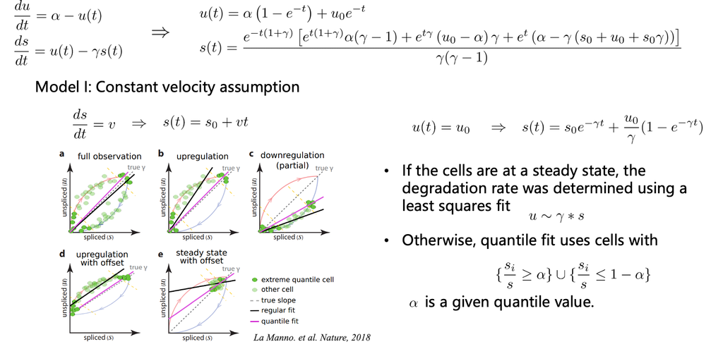

Figure 7 — How γ is estimated when the cells are *not* at steady state. Regular least squares on all cells gives the wrong slope (black lines); restricting the fit to the extreme quantiles of s (green) recovers the true slope (dashed). This is the `perc=[5,95]` default of `scv.tl.velocity`.

The quantile trick is the answer to “but cells are not at steady state”. The extreme-quantile set {sᵢ/mean(s) ≥ α} ∪ {sᵢ/mean(s) ≤ 1−α} picks cells whose spliced content is extreme, and for those the trajectory is nearly linear, so a straight-line fit through them recovers γ even when the middle of the portrait is curved. It is an approximation with a name and a default (5/95), not a neutral choice: the `perc` value enters every γ, hence every velocity in the notebook (VELO-05).

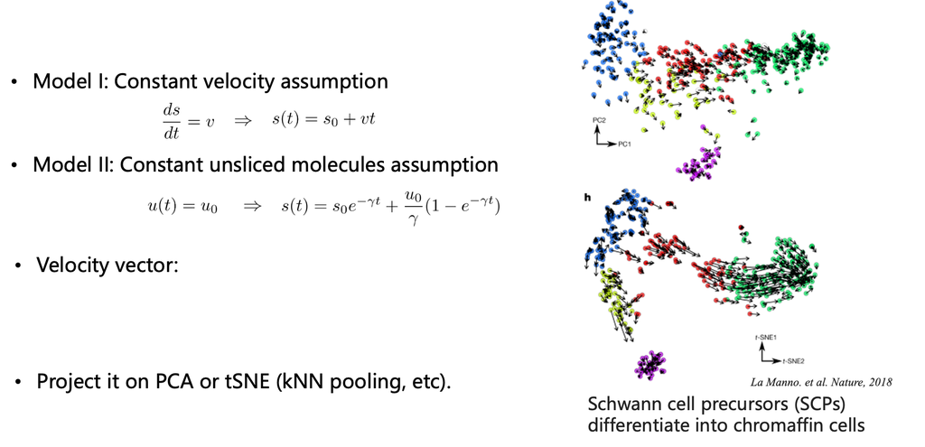

Figure 8 — Steady-state velocity as a field. The residual u − γs per cell, projected onto PCA and t-SNE by kNN pooling, orients the Schwann-cell-to-chromaffin-cell transition in the mouse adrenal gland. From La Manno et al., 2018.

## 6. Theory III — the dynamical model, which is the one the slides actually teach

The last two theory figures describe the model the notebook *does not run*. Instead of estimating one γ per gene from a straight line, the dynamical model fits the full transcription kinetics: α is allowed to switch on and off, β and γ are per-gene, and every cell gets a latent time.

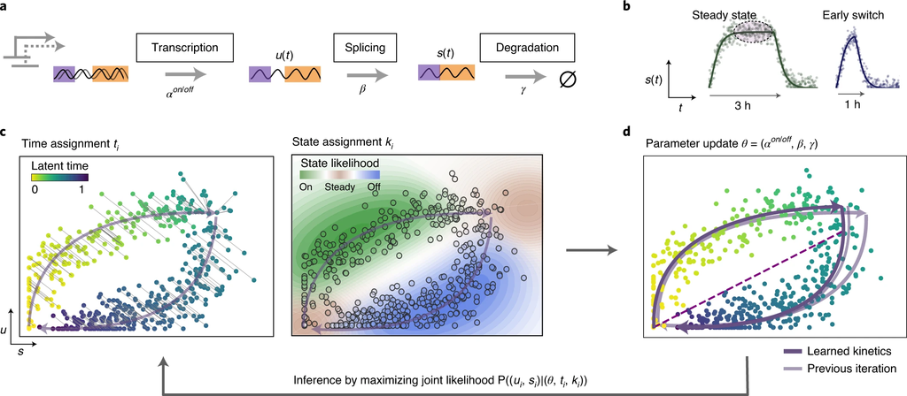

Figure 9 — The dynamical model of Bergen et al. (2020). `a`: transcription (on/off), splicing and degradation with per-gene rates. `b`: the same gene under steady state (left) and under an early switch (right) — the two produce the same steady-state line and different trajectories. `c`: the EM loop — assign each cell a latent time tᵢ and a state kᵢ ∈ {on, steady, off}, then `d`: update θ = (α^on/off, β, γ) by maximising the joint likelihood; repeat until the learned kinetics (dark) stop changing.

Concretely, the estimator maximises P(u, s | θ, t, k) over the parameters *and* the per-cell latent time simultaneously. Two things follow that the steady-state model cannot give: a per-gene likelihood (so badly fitting genes can be filtered rather than silently averaged in), and a *shared* latent time that orders all cells of all clusters on one axis — the object that later became CellRank’s pseudotime and the reason `latent_time` appears in so many downstream tools.

The last slide puts the whole family in one frame and is the most useful orientation in the deck: the model you can fit depends on the assay you have.

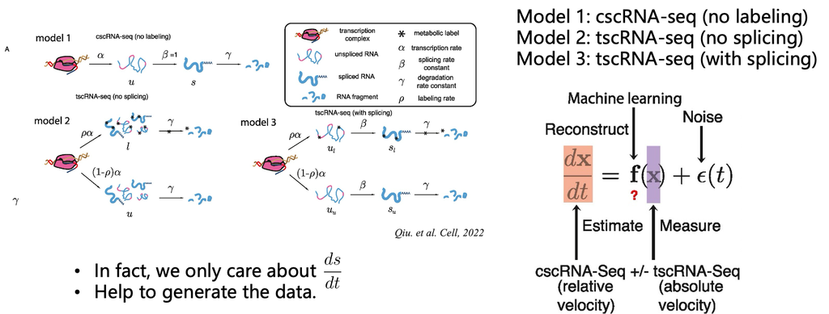

Figure 10 — Three assays, one derivative. `Model 1` cscRNA-seq without labelling (relative velocity), `models 2/3` tscRNA-seq with a metabolic label and labelling rate ρ (absolute velocity), and the general form dx/dt = f(x) + ε(t) in which machine learning supplies f and noise. From Qiu et al., 2022.

“cscRNA-seq (relative velocity)” versus “tscRNA-seq (absolute velocity)” is the sentence to keep. Every velocity in this notebook is relative: it says which way along the manifold a cell is moving, and it does not say how fast in hours. Reading `latent_time`, `velocity_confidence` or the arrow lengths as if they carried physical units is the most common misinterpretation of the whole method.

## 7. Step 0 — the object, and the three things it hides

The tutorial spends four cells on the loaded object: shape, layers, proportions, and a print of the matrix corner. Three of those cells mislead, none fatally.

**Units.** After step 1, `adata.X` is log-normalised while `layers['spliced']`/`layers['unspliced']` stay linear-normalised (VELO-02; measured maxima 7.31 vs 1488.7 and 573.3). This is deliberate — the velocity model is defined on linear counts, and scanpy’s HVG selection wants logs — but nothing in the notebook says it, and every phase portrait in the second half of the lesson plots `spliced` against `unspliced`, i.e. the linear layers. A student who “reproduces” a phase portrait with `adata.X` gets a different picture.

**The var column.** `adata.var.head(3)` shows a single column, `highly_variable_genes`, with values True/False/NaN. It looks like the HVG selection and is not: on the full matrix it holds 4,004 True, 13,338 False and 10,656 NaN, whereas the selection the tutorial uses is scanpy’s `highly_variable` (2,000 True after `subset=True`). The column is a leftover annotation shipped with the data set, and `var.head(3)` is the one place it becomes visible (VELO-07).

**The proportions figure.** This is the cell that looks most like a quantitative result and is the least reproducible one, for a reason worth knowing:

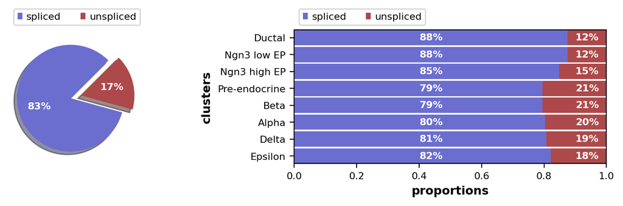

| cluster | unspliced share, `initial_size` (what the figure shows) | unspliced share, current layers |
| --- | --- | --- |
| Ductal | 12.3% | 21.0% |
| Ngn3 low EP | 12.4% | 21.8% |
| Ngn3 high EP | 15.0% | 25.0% |
| Pre-endocrine | 20.5% | 25.3% |
| Beta | 20.7% | 23.7% |
| Alpha | 19.5% | 21.6% |
| Delta | 19.3% | 19.9% |
| Epsilon | 17.9% | 20.9% |
| all cells | 16.3% | 23.0% |

Both are legitimate quantities; they answer different questions. The figure’s version is “how much of the sequenced library was intronic in this population”, which is assay-level and says something about library preparation. The layers’ version is “how much unspliced signal does the velocity model actually see after filtering”, which is what the model runs on. The tutorial presents the first and the reader will recompute the second — hence the entry in the issue list.

The cell that prints `adata.X[:5,:10]` (VELO-06) is cosmetic by comparison: on a sparse matrix that slice prints coordinate triplets, not a block of numbers, and the tutorial’s own output shows the truncated tail of that dump rather than a matrix.

## 8. Step 1 — filter, normalise, log, select, smooth

Five calls, and the only one with a real trap is the first.

**`scv.pp.filter_and_normalize(adata, min_shared_counts=20)`.** Genes are kept only if they have at least 20 counts summed over *both* spliced and unspliced in at least one cell; the object then loses 20,801 of 27,998 genes and keeps 7,197. Then each layer is library-size normalised to its median. Note what the call does **not** do: the docstring still says “Filtering, normalization and log transform” and the parameter list still mentions a log, but the 0.3.4 implementation only runs `filter_genes` + `normalize_per_cell` (VELO-01). The tutorial’s separate `sc.pp.log1p` is therefore required, not redundant — the pre-registered “double log” suspicion is wrong, and this is the one place where the planning pass had to be retracted after measurement.

**`sc.pp.log1p(adata)`.** Logs `X` only. `scv.pp.moments` and everything velocity-related read the layers, so the model stays linear; `sc.pp.highly_variable_genes` reads `X`, so selection is done on logs. Both are standard and both are invisible in the notebook (VELO-02).

**`scv.pp.moments(n_pcs=30, n_neighbors=30)`.** Two things in one call. It computes kNN-smoothed expression `Ms`/`Mu` — the average of spliced/unspliced over each cell’s 30 nearest neighbours in PCA space — which is what makes per-cell velocities quiet enough to plot. And, in 0.3.4, it also builds the neighbour graph itself if one is missing, which is the deprecated path (VELO-04) and the source of the “Automatic neighbour calculation is deprecated” warning in the as-written log. The corrected pass builds neighbours explicitly with `sc.pp.neighbors(n_neighbors=30, use_rep="X_pca", n_pcs=30, random_state=...)` and then calls `moments` on the existing graph.

The smoothing is not optional decoration. With 30 neighbours, `Ms` has 1,740,903 non-zeros against the raw 9.3 M spliced counts: each cell’s velocity is an average over 31 cells, which is why the stream plots look smooth and why small populations get noisy — Delta has 70 cells, so its velocity field is an average over 70 × 31 cells with heavy overlap.

**Pitfalls.** Filtering genes on shared counts *before* HVG selection means the 2,000 HVGs are chosen from 7,197 candidates, not from 27,998; that ordering is correct for velocity (a gene needs unspliced counts to be usable) but it makes the HVG set incomparable to a standard scanpy pipeline. And the choice of `min_shared_counts=20` is scale-dependent: it is a count threshold, so a data set with half the sequencing depth loses far more genes. Measured on this object, the threshold sweeps 27,998 genes down to 9,364 (5) · 8,357 (10) · 7,197 (20) · 5,368 (50) · 3,987 (100) — a factor of 2.3 in gene universe between the two ends of a plausible range, which the tutorial never shows.

**Tuning.** The three parameters that matter are `min_shared_counts` (depth scale), `n_top_genes` (breadth of the gene universe, §14) and `n_neighbors` in `moments` (smoothing, §14). `n_pcs=30` interacts with the shipped 50-component PCA in a way the tutorial does not discuss: the velocity graph is built on the first 30 of the 50 shipped components, while the UMAP the arrows are drawn on was fitted on all 50 (VELO-09). Recomputing the PCA from the 2,000 HVGs instead moves the top-20 ranking by Jaccard 0.78 — the smallest of the four parameter effects, but the one that is invisible in the notebook.

## 9. Step 2 — the steady-state model and the velocity graph

The tutorial’s analysis cell is a single line, `scv.tl.velocity(adata)`, and the default `mode` in 0.3.4 is `"stochastic"` — the steady-state estimator of §5 with the γ fitted from moment statistics rather than from the residual line. What it computes per gene is a slope through the origin of Mu on Ms at the extreme quantiles (`perc=[5,95]`), then per cell a residual v = Mu − γ·Ms; what it stores is a velocity layer with 2,000 columns, 1,038 of which carry a non-zero “velocity gene” flag (`velocity_genes`), the rest zeroed out because their fit did not pass the r²/ratio filters (`min_r2=1e-2`, `filter_genes=False`). The object also gains `velocity_gamma` (median 0.343, IQR [0.090, 0.966] across the 2,000 genes — this is the per-gene slope), `velocity_r2` (median 0.052, IQR [−0.359, 0.444]) and `velocity_qreg_ratio`.

Those r² values are the first thing a careful reader should look at: the median gene explains 5% of the variance around the steady-state line. On this data set that is expected — most HVGs are not in a velocity-relevant process — but it also means the 1,038 “velocity genes” flag is a low bar, not a quality statement. The tutorial never prints it.

**The graph is what the plots use.** `scv.tl.velocity_graph(adata)` converts per-gene velocities into a cell-to-cell transition matrix: for each cell it compares its velocity vector with the expression difference to each of its 30 neighbours (cosine similarity) and normalises the rows. The stored matrix has 593,854 non-zeros out of 13.7 M entries. Everything visual — stream plot, arrow plot, latent time, velocity confidence, the cycle panel — is derived from this graph, not from the raw per-gene velocities. That is why the field looks smooth even though individual genes are noisy, and it is also why a wrong neighbour graph (wrong space, wrong k) corrupts every figure at once.

Two practical notes the tutorial does not make. First, the call is single-threaded by default: the as-written log says “using 1/32 cores” and takes 9 s on this small object; with `n_jobs=-1` it takes 6–7 s at 32 cores, and on a 100k-cell object the difference is the difference between minutes and an hour. Second, the calculation is exact but not seeded — different runs give slightly different graphs, so a paper-grade result needs a fixed seed on the upstream neighbour computation, which the corrected pass sets (`random_state=0`).

**Pitfalls.** `scv.tl.velocity` respects `use_highly_variable=True` by default, so a reader who skipped the HVG subset gets a different gene universe with no warning. The velocity layer is dense in memory (n_cells × n_genes float32) even though only ~52% of genes are non-zero: 3,696 × 2,000 × 4 B = 29.6 MB here, 800 MB at 100k cells, which is the usual reason pipelines OOM at this step. And the `velocity_graph` in `uns` is a scipy sparse matrix, not an array — `adata.uns['velocity_graph']` is not JSON-serialisable, so `adata.write()` (h5ad) is fine but a Zarr export needs care.

**Tuning.** `perc` (the quantile band used for the γ fit), `n_recurse_neighbors` (how far the graph reaches; 0 here), `mode_neighbors='distances'` vs `'connectivities'` (the tutorial uses distances through `moments`), and `min_r2` (how many genes survive as velocity genes). Of these, `perc` has the largest effect on the field and is the one place where a sensitivity table is worth computing on your own data; the corrected pass leaves it at the tutorial’s value because changing it changes the question rather than the answer.

## 10. Step 3 — the model the slides teach, finally run

Three lines the tutorial never executes:

```python
scv.tl.recover_dynamics(adata, var_names="all", n_jobs=8)   # 2:35 on 8 cores, 2,000 genes
scv.tl.velocity(adata, mode="dynamical")                    # 7 s
scv.tl.latent_time(adata); scv.tl.velocity_confidence(adata)
```

**VELO-17, found while running this: the model’s gene universe is inherited.** `recover_dynamics` defaults to `var_names="velocity_genes"`, i.e. it fits only the genes the *previous* velocity run flagged. Run stochastic then dynamical — the natural order, and the one the tutorial implies — and the EM is silently restricted to the steady-state model’s 1,038 genes; the two models are then not even fitted on the same gene set, and the dynamical ranking cannot see 962 of the 2,000 HVGs. Passing `var_names="all"` fixes it. Measured both ways: with 1,038 genes the fit takes 1:29 and yields 849 dynamical velocity genes; with all 2,000 it takes 2:35 and yields 1,078. The **top five genes per cluster are identical in both cases**, and the stochastic-vs-dynamical top-20 Jaccard is 0.132 in both — so the disagreement below is a property of the models, not of the inherited gene list.

**What came out.** The fitted kinetics are plausible for the assay: median `fit_gamma` = 0.263 (IQR [0.181, 0.406]) over the 2,000 genes, median `fit_likelihood` = 0.242 with 1,999 of 2,000 genes above zero, and `fit_t_` (the inferred switch time) spanning 0–18 in the model’s own units. The latent time is the object that reorganises the whole data set on one axis, and it recovers the known hierarchy without being told the clusters:

| cluster | cells | latent time (median) | velocity confidence (median) |
| --- | --- | --- | --- |
| Ductal | 916 | 0.157 | 0.826 |
| Ngn3 low EP | 262 | 0.156 | 0.825 |
| Ngn3 high EP | 642 | 0.465 | 0.870 |
| Epsilon | 142 | 0.703 | 0.862 |
| Delta | 70 | 0.714 | 0.944 |
| Pre-endocrine | 592 | 0.743 | 0.900 |
| Alpha | 481 | 0.758 | 0.823 |
| Beta | 591 | 0.742 | 0.900 |

Ductal and Ngn3-low at the beginning, Ngn3-high in the middle, the three endocrine fates at the end — the same order the biology predicts and the same order the stream plot suggests, but now on a one-dimensional axis per cell rather than a two-dimensional embedding. Two details are worth noticing. Delta and Epsilon land *between* Ngn3-high and Pre-endocrine, which is where the delta/epsilon lineages branch off, not at the terminal end. And Beta’s median (0.742) is *earlier* than Alpha’s (0.758) while its mean (0.774) is later — the distribution is skewed, so the median and the mean tell different stories about the β-versus-α ordering; that is a real limitation of a global latent time, and reporting one number per cluster hides it.

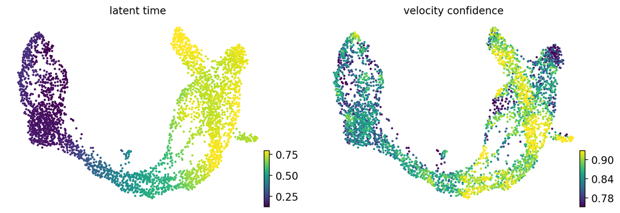

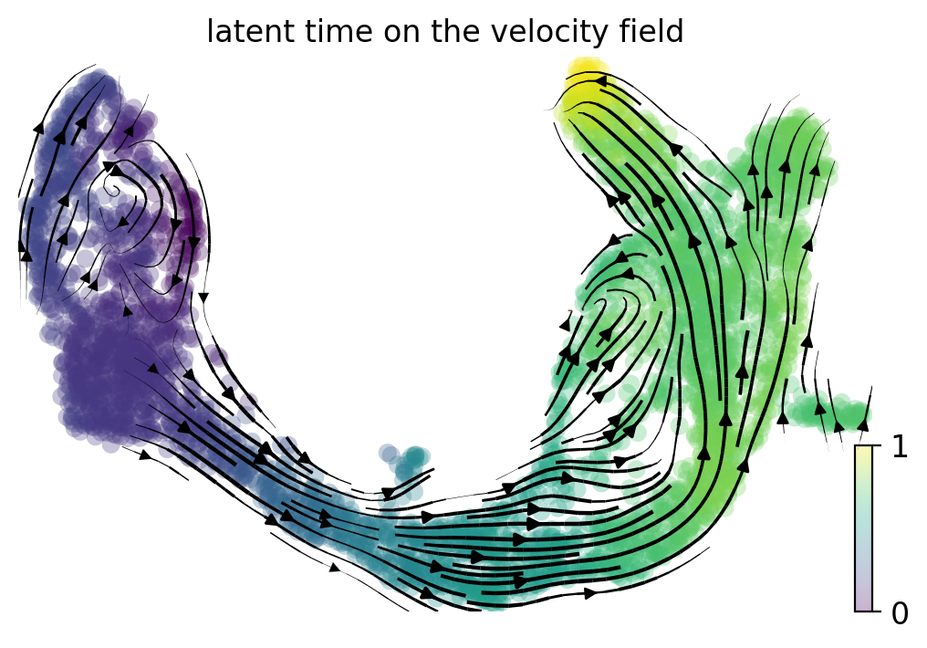

Figure 13 — The stream plot coloured by latent time: the same region of the field as Figure 14, with the time axis the dynamical model inferred. The warm end of the colour bar is the endocrine fate.

**The two models disagree, and the disagreement is the lesson.** Across clusters the mean top-20 Jaccard between the stochastic and dynamical velocity-gene rankings is **0.132** — that is, the two models rank the same data in ways that share only an eighth of their top genes. The global flow is similar (stream plots correlate 0.93–0.98 with each other and with the teacher’s), the latent ordering is consistent with it, and yet the gene-level answer — the thing §12 prints as a table — is essentially model-dependent. Two further measurements make the same point from different sides:

- `velocity_confidence` for the two models correlates at only **0.207** (dynamical median 0.859 vs stochastic 0.815). The confidence field, which looks like a quality metric, is itself model-dependent.
- The steady-state γ and the kinetic γ are not interchangeable: their ratio has median 0.85 but an IQR of [0.23, 4.07], and a Spearman rank correlation of **−0.45** across the 2,000 genes. They are different parameterisations (the steady-state model normalises β = 1), so only the ordering is comparable — and the ordering disagrees. The “one shared splicing rate” that the steady-state model assumes is not a scaled version of the rate the EM learns.

**Pitfalls.** `recover_dynamics` is the expensive step and the one that fails first on big data (memory, and `n_jobs` oversubscription — 8 was the sweet spot on a 32-core node here). `latent_time` is a quantile, 0–1, not minutes: it is built from the fit’s t_ rescaled per cell, and its absolute value has no meaning across data sets. `velocity_confidence` is a graph-consistency score (clipped at 0), not a posterior probability, and its threshold for “trustworthy” does not exist. And genes with low `fit_likelihood` are still in the `velocity` layer unless you filter with `scv.tl.filter_genes`/`min_likelihood` — the flag `velocity_genes` (1,078 here) is the only built-in guard.

**Tuning.** `max_iter`, `fit_scaling`, `fit_steady_states` and `steady_state_prior` all change the fit in ways that matter for switch-like genes; the defaults are the paper’s defaults and are a reasonable starting point. The one parameter that must not be left at the default in a re-analysis is `var_names` (VELO-17).

## 11. Step 4 — reading the velocity field

Three figures carry the tutorial’s interpretation, and they fail in different ways.

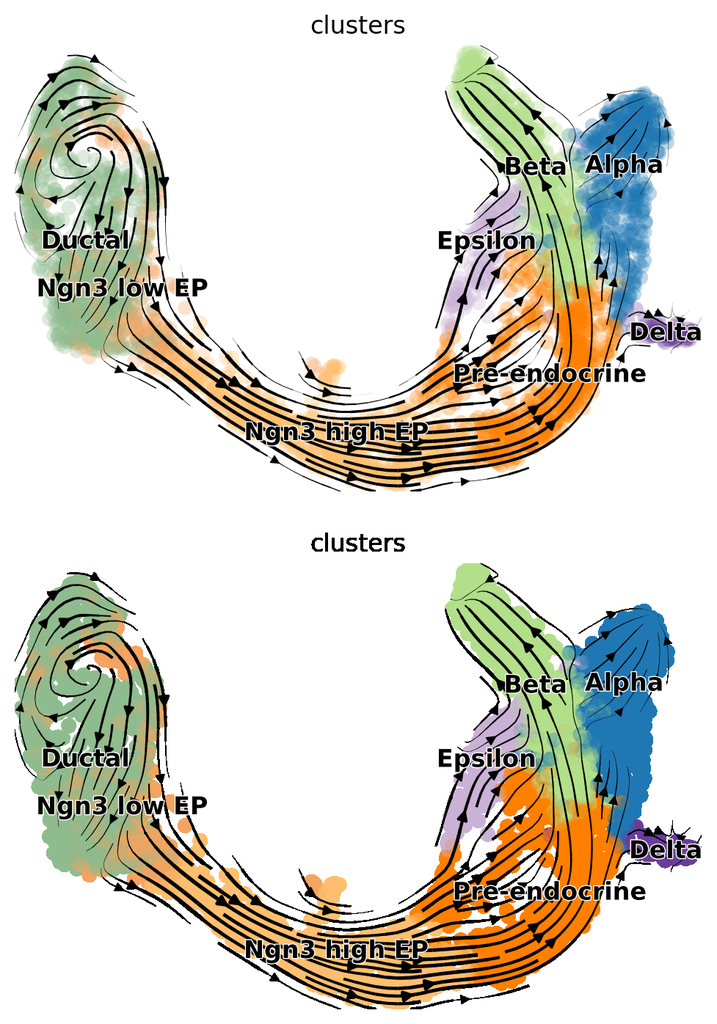

Figure 14 — The velocity stream plot, teacher’s rendering (top) and the as-written run (bottom). Structural correlation 0.982, ink IoU 0.96. The flow runs from the Ductal/endocrine-progenitor region (left) through the Ngn3-low and Ngn3-high branches, into Pre-endocrine, and out to Alpha and Beta; Delta and Epsilon sit off the main path.

The stream plot is the figure the lesson is remembered by, and it is a good picture: the field is consistent with the known biology of E15.5 pancreas (endocrine progenitors delaminating from the ductal epithelium, then branching into α/β/δ/ε), and it reproduces the teacher’s rendering almost exactly. What the picture does *not* say, and what the notebook does not say either, is:

- **Arrows are not trajectories.** The field is the average velocity of a cell’s 30 neighbours’ velocities, projected onto a UMAP that was fitted independently of the velocity graph (VELO-09). Two nearby cells with similar expression can have opposite arrows; the stream plot’s smoothing is a rendering choice, not a claim about individual cells.
- **The divergence structure is invisible.** Nothing in the plot distinguishes a genuine branch point from a place where two unrelated populations are adjacent in the embedding. The standard fix is CellRank’s transition matrix on the same graph, which does distinguish them, and which is the natural next step (Appendix B).
- **Small populations are unreliable.** Delta has 70 cells and Epsilon 142; with k=30 smoothing each cell in those populations is heavily influenced by its neighbours outside the population. The arrows near those clusters are the noisiest part of the figure and the one place a reader is most likely to over-interpret.

The arrow plot (`03_velocity_embedding.png`) is the same information without interpolation and is useful precisely because it shows the per-cell noise the stream plot hides.

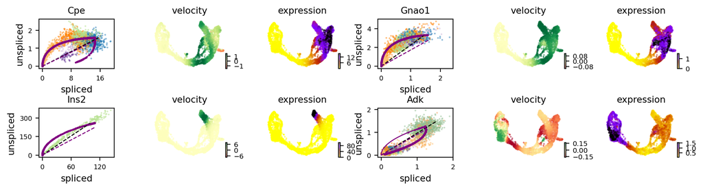

Figure 15 — Phase portraits of Cpe, Gnao1, Ins2 and Adk, coloured by velocity, drawn by the corrected pass with the stochastic (steady-state) estimator. Note the sign flips along each trajectory: this is the quantity the whole lesson is built on.

The tutorial’s own four genes are well chosen: `Cpe` is a marker of the endocrine-progenitor branch and shows a clean loop, `Gnao1` a monotone rise, `Ins2` the extreme case (spliced up to 120, i.e. the mature insulin transcript dominates the mature pool and the portrait collapses onto a line), `Adk` a wide cloud where the velocity signal is weakest.

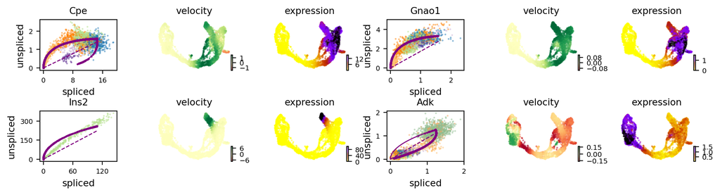

Figure 16 — The same four genes with only the dynamical fit drawn (`fits=["dynamics"]`). Compare the curves with Figure 15’s: where the two models agree the fitted trajectory follows the steady-state line; where they disagree you can see which cells the EM thinks are in transcription-on versus -off state.

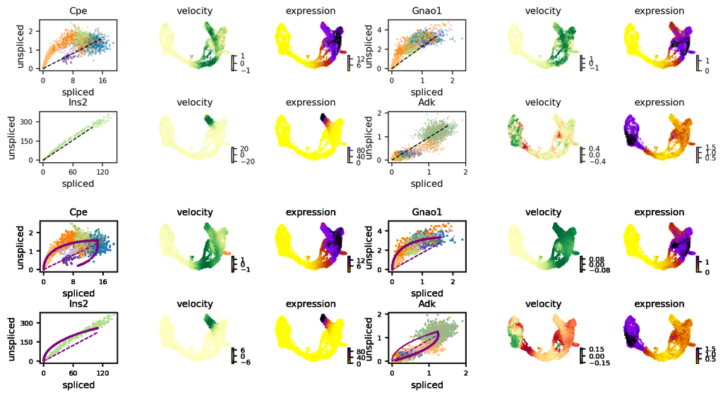

Figure 17 — Teacher’s phase-portrait panel (top) against the corrected pass (bottom). Correlation 0.956, same 3.69 aspect; the reference is rendered at a smaller dpi, which is why the canvas differs (VELO-15).

**The `mode` trap (VELO-16).** The tutorial draws the portraits twice — `scv.pl.velocity(..., ncols=2)` in cell 69 and the same call with `mode="dynamical"` in the text that follows — implying that `mode` selects the model. It does not. `mode` only controls whether the two extra variance panels are drawn: the curves inside the portrait come from the `fits` argument, whose default is `["velocity", "dynamics"]`, so the plain call already overlays the dynamical fit and the dynamical call produces a **byte-identical** figure (verified: same md5). The corrected pass replaces the redundant call with `fits=["dynamics"]`, which is the argument that actually isolates the model’s own curve.

## 12. Step 5 — velocity genes, and what `min_corr` really filters

`scv.tl.rank_velocity_genes(adata, groupby='clusters', min_corr=.3)` produces the table that most students take as “the result”: for each cluster, the genes whose per-cell velocity correlates with the gene’s own expression profile across cells. The top five per cluster, from the as-written run:

| cluster | top 5 (stochastic model) | top 5 (dynamical model) |
| --- | --- | --- |
| Ductal | Notch2 / Sox5 / Krt19 / Hspa8 / Ano6 | Notch2 / Adamts16 / Tcf7l2 / Bcl11b / Krt19 |
| Ngn3 low EP | Ptpn3 / Hacd1 / Hspa8 / Gm8113 / Kcnq1 | Adamts16 / Notch2 / Idh2 / Hspa8 / Cnksr3 |
| Ngn3 high EP | Pde1c / Ptprs / Pclo / Rap1gap2 / Ttyh2 | Ptprs / Sel1l / Vwa5b2 / Tgfbr1 / Mtch1 |
| Pre-endocrine | Pam / Sdk1 / Baiap3 / Abcc8 / Gnas | Syt7 / Abcc8 / Scg5 / Baiap3 / Pcsk2 |
| Beta | Pax6 / Unc5c / Nnat / Tmem108 / Ptprt | Kctd8 / Nnat / Sphkap / Sdk2 / Zbtb7c |
| Alpha | Zcchc16 / Nlgn1 / Nell1 / Prune2 / Ksr2 | Skap1 / Gpr179 / Rab27a / Nfasc / Rasgrf2 |
| Delta | Zdbf2 / Spock3 / Akr1c19 / Ptprt / Snap25 | P2ry1 / Pdia5 / Gpr179 / Hat1 / Nucks1 |
| Epsilon | Tmcc3 / Heg1 / Gpr179 / Ica1 / Ncoa7 | Gpr179 / Prdx4 / Rab27a / Syt13 / Dock11 |

The two columns are the same data set, the same clusters and the same call — the only difference is which velocity layer the ranking reads. They agree where the biology is unambiguous (Notch2 and Krt19 in ductal, Ptprs in Ngn3-high, Abcc8/Baiap3 in Pre-endocrine, Nnat in Beta, Gpr179 in Epsilon) and disagree almost everywhere else: of the 40 slots in the table only 8 are filled by the same gene, and two clusters (Alpha and Delta) share nothing at all. The mean top-20 Jaccard across clusters is 0.13. That number is the case for running the model the course teaches: **if you publish a velocity-gene list from the steady-state mode, it is not the list the dynamical model would give you, and the tutorial gives no way to know that.**

Three properties of the ranking call are worth stating, because the parameter names mislead:

- `min_corr` does **not** filter the correlation of the ranking. It filters genes by `adata.var['spearmans_score']` (the global velocity–expression correlation) before ranking. Measured sweep: thresholds 0.1 / 0.3 / 0.5 / 0.7 leave 1,861 / 1,469 / 973 / 430 genes eligible, and the visible top-3 of Ductal and Beta is **unchanged** for all four — because the next point dominates.
- `n_genes` (default 100) is the actual truncation. The table has exactly 100 rows per cluster at the default, 10 at `n_genes=10`, 300 at `n_genes=300`. Since 1,469 genes pass `min_corr=.3`, the tutorial’s “threshold” never bites and its “100 genes per cluster” is a display cap, not a filter.
- The ranking is *within* cluster: a gene can be top-5 in two clusters (Ptprt appears in Beta and Delta, Gpr179 in Alpha, Delta and Epsilon), which is correct behaviour but reads oddly in a per-cluster table.

## 13. Step 6 — the cell cycle: how a confounder becomes a figure

`scv.tl.score_genes_cell_cycle(adata)` reimplements the Tirosh S/G2M scoring: it takes the hard-coded marker lists, scores each cell by the mean expression of the S and G2M genes relative to a control-gene set, and stores `S_score`/`G2M_score` **overwriting whatever was there** (VELO-08). On this object the shipped scores and the recomputed ones are close but not identical:

|  | shipped | recomputed | Pearson |
| --- | --- | --- | --- |
| S_score mean | −0.088 | −0.003 | 0.964 |
| G2M_score mean | −0.136 | −0.109 | 0.973 |
| phases (G1/S/G2M) | — | 2,537 / 878 / 281 | — |

A reader who assumes the tutorial’s figure shows the data’s own annotation is wrong by a few percent per cell — enough to reorder cells near the S/G2M boundary, not enough to change the picture. The dangerous version of this bug is on data where the shipped scores came from a *different* marker set or a different organism; then the overwrite silently invalidates every downstream interpretation, and scVelo does not warn.

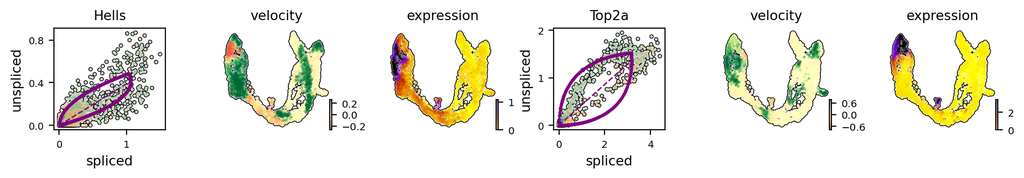

Figure 18 — Hells and Top2a phase portraits with the dynamical fit. These are the genes the tutorial uses to explain why cycling cells must be handled: their velocity points *backwards* along the differentiation axis, because the lineage-committed cell re-enters the cycle.

The biology the tutorial is pointing at with these two genes is real and important: in a differentiating trajectory, proliferating cells cycle, and cycling genes produce a velocity component that is orthogonal (or antiparallel) to the fate direction. If a cluster is mostly cycling cells, its velocity can point toward G1 rather than toward the next cell type. The tutorial shows the portraits but never connects the two: it plots `color_gradients=['S_score','G2M_score']` as a *decorative* overlay and does not regress the cycle out, filter cycling cells, or check whether the S/G2M gradient explains any of the arrows.

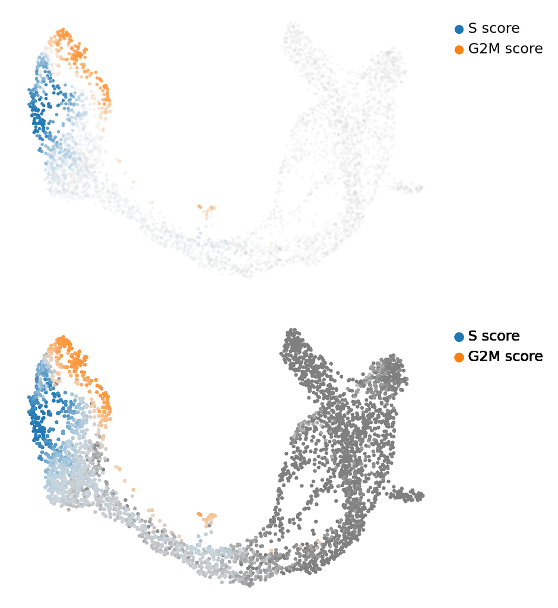

Figure 19 — The cell-cycle gradient panel: teacher’s rendering (top) and the as-written run (bottom). The only figure of the eleven that does not reproduce: structural correlation 0.589, ink IoU 0.34, marker ink 12% against our 14%, identical canvas and identical legend text.

This is the one reference PNG that cannot be reproduced (VELO-15). The diagnosis is in §3.3: the canvas and the legend are identical, the colours inside the marker clouds are not, so the reference was drawn by a different scVelo build. It is worth being explicit that the *quantitative* content is unaffected — the scores themselves reproduce to Pearson 0.964/0.973 — and that our own figure is reproducible: the same code, run twice, gives a byte-identical PNG.

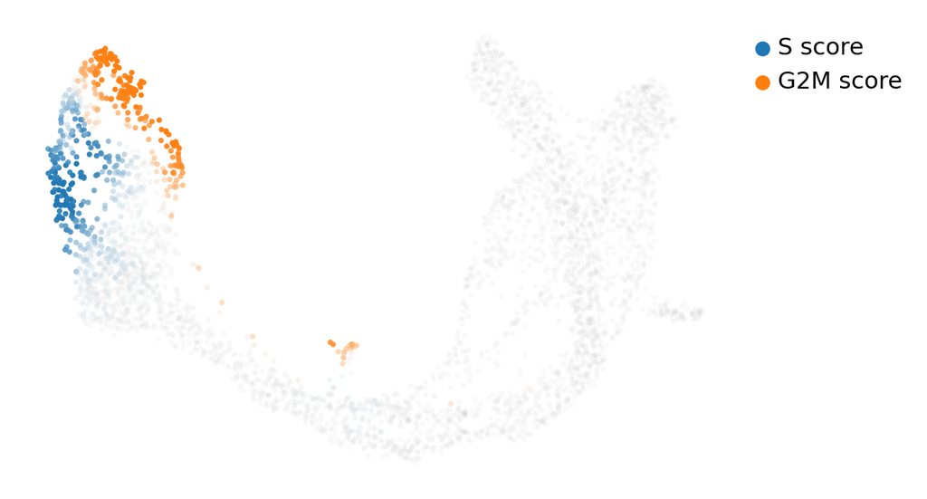

Figure 20 — The same panel drawn by the corrected pass with the scores the data set shipped, instead of the ones the tutorial overwrites. Visually almost the same figure — which is exactly why this bug survives in the wild.

**What to do about the cycle in practice.** Three options, in increasing order of honesty: (i) plot the gradient and note it (what the tutorial does); (ii) score the cycle, regress it out of `Ms`/`Mu` and recompute velocity (common in the literature, but the regression also removes real signal — cells in G2M genuinely express more of everything); (iii) test whether it matters — compute velocity with and without the cycling cells, and report whether the branch structure changes. The corrected pass does (iii) implicitly by keeping the cycle in the object and providing `cellcycle_scores_original_vs_recomputed.csv` plus the per-cell latent time, so a student can colour the stream plot by `S_score` and see the gradient for themselves.

## 14. Step 7 — what the tutorial’s unexplained defaults cost

Five numbers in this notebook are chosen without justification: `n_top_genes=2000`, `n_neighbors=30`, `n_pcs=30`, `min_corr=.3` and the shipped PCA/UMAP. The corrected pass sweeps them — six full stochastic pipelines, each from the raw file — and records how much the answer moves.

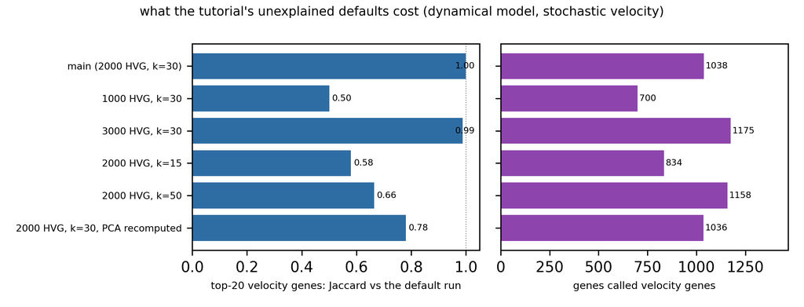

[output not shown]

What this table is *for* is the sentence “report your parameters and show one sweep”. A reader cannot tell from the tutorial whether its conclusions depend on 2,000 HVGs; after this table we know they depend on being somewhere between 1,000 and 3,000, and on k being near 30.

## 15. The corrected pass

The corrected script (`results/scripts/scVelo_py_cells_corrected.py`) keeps every tutorial parameter that is a modelling choice and changes only what the issue list says is wrong or missing. It runs in 4.7 min and writes 13 figures and 17 tables; the audit script then re-derives the numbers from the stored object, so nothing below depends on the script that produced it.

**What changed.**

- **A seed.** `random_state=0` on the PCA/neighbour calls, and an explicit `sc.pp.neighbors` before `moments` (VELO-04, VELO-12). The as-written pipeline is not bit-reproducible; this one is.
- **The dynamical model is run** on all 2,000 genes (VELO-03, VELO-17), with latent time and both confidence variants kept. This is the change that changes the lesson.
- **The proportions figure is computed both ways** (VELO-14): the `initial_size` version for comparison with the teacher’s PNG, and the current-layers version for the table, so the 16.3% vs 23.0% discrepancy is documented rather than inherited.
- **The cell-cycle scores are not overwritten** (VELO-08): the figure is drawn from the scores the data set shipped, and the recomputed pair is written to `cellcycle_scores_original_vs_recomputed.csv` so both are available with their Pearson values.
- **The duplicated stream figure is replaced** (VELO-10) by two panels the tutorial never draws: the stream plot coloured by latent time, and latent time plus confidence per cell.
- **`mode="dynamical"` → `fits=["dynamics"]`** (VELO-16), which is the argument that actually isolates the model’s curve.
- **Deprecation-clean APIs**: `sc.pp.neighbors` + `moments` instead of `moments` building its own graph; `latent_time`/`velocity_confidence` instead of `scv.get_df`; no call that emits a 0.4.0 warning.
- **Everything is persisted**: the object (`corrected_adata.h5ad`, 410 MB, regenerated by one `adata.write()`), 17 tables, 13 figures, and the console log.
- **The cycle/ranking/phase tables** that the tutorial computes and discards are written out.

**What did not change.** `min_shared_counts=20`, `n_top_genes=2000`, `n_neighbors=30`, `n_pcs=30`, `perc=[5,95]`, `min_corr=.3`, the cluster labels, the embedding, the four tutorial genes, the Hells/Top2a pair, and the `fits` default when drawing the “both models” panel. Every deviation above is either a bug, a deprecation, a missing analytical step or a missing output — none is a change of question.

**How faithful is the corrected pass?** Its figures are *not* supposed to match the teacher’s beyond the shared rendering, because after step 3 the velocity field is the dynamical one. The comparison therefore measures “does the corrected pipeline still see the same biology”:

| corrected panel | reference | structural corr | ink IoU |
| --- | --- | --- | --- |
| 01 proportions | 01_proportions | 0.986 | 0.92 |
| 02 stream | 02_velocity_embedding_stream | 0.934 | 0.90 |
| 03 arrows | 03_velocity_embedding | 0.904 | 0.82 |
| 04 phase portraits (stochastic) | 04_phaseportrait_markers | 0.956 | 0.87 |
| 05 phase portraits (dynamical fits only) | 04_phaseportrait_markers | 0.957 | 0.87 |
| 06 Cpe groups+velocity | 05_cpe_groups_velocity | 0.965 | 0.87 |
| 07 top5 Ngn3-high | 06_top5_ngn3_high_ep | 0.977 | 0.93 |
| 08 top5 Pre-endocrine | 07_top5_pre_endocrine | 0.983 | 0.93 |
| 09 cell cycle (shipped scores) | 08_cellcycle_gradients | 0.579 | 0.34 |
| 10 phase-marker genes | 09_phase_marker_genes | 0.905 | 0.86 |
| 11 Hells/Top2a (dynamical) | 10_phaseportrait_hells_top2a | 0.948 | 0.91 |
| 12 latent time + confidence | — | new | new |
| 13 stream coloured by latent time | 02_velocity_embedding_stream | 0.746 | 0.72 |

Two numbers deserve comment. The stream plot drops from 0.982 (as-written) to 0.934 when the field becomes the dynamical one — that 5-point gap is the visible part of the model difference, and it is smaller than the gene-ranking disagreement of §12 would suggest, because both fields agree on the global geometry and disagree on the fine arrows. The latent-time stream (0.746) differs more, as it must: the colouring is a different quantity, not a different field, and the correlation is measuring the colour map, not the flow.

**The one thing the corrected pass still cannot reproduce** is the teacher’s cell-cycle panel (0.579). Its canvas and legend are identical, its colour map is not: the reference was drawn by a different scVelo build (§3.3). Our own reproduction of that panel is deterministic (run twice → same md5), so the gap is on the reference side.

## 16. Corrections we deliberately did not make

Four questions a reviewer will ask, and why each is out of scope for a “faithful run + correction” module.

**Velocity on the full 7,197-gene universe.** The tutorial restricts velocity to 2,000 HVGs; the honest alternative is to compute it on every gene that passed the shared-count filter and use only the ranking as a filter. That is a 3.6× cost in the expensive steps and a different question, so it was replaced by the HVG-depth sweep (§14), which measures the sensitivity without pretending to be a correction. If you need it: drop `subset=True`, run `moments` with the same k, and expect the velocity layer at 2,000 genes to be a subset of the result.

**Batch correction.** The data set is one 10x run at one time point; there is no batch to correct. The general lesson (Harmony/BBKNN before `moments`) belongs in a module with a multi-sample object, and applying it here would be cargo cult.

**A fate-probability analysis.** The natural next step after velocity on a branching manifold is CellRank (transition matrix + absorbing states + fate probabilities), which replaces “the arrow points that way” with “this cell is 0.73 naive and 0.21 alpha”. It is a separate library with its own tutorial and would double the scope; Appendix B gives the three-line bridge.

**Re-running the teacher’s eleven figures at their exact dpi to reach pixel equality.** The three dpi values in the reference (VELO-15) make “the” reference ambiguous, and matching dpi exactly proves nothing about the analysis. The comparison normalises canvases and compares structure, which is the honest measure; §3.3 documents the dpi groups so a future reader can reproduce any one of them.

## 17. Reproducing this module

```bash
# 0. environment (once)
conda create -y -n velo python=3.11 && conda activate velo
pip install "scvelo==0.3.4" "scanpy==1.10.4" "anndata==0.11.4" "numpy==1.26.4" \
            "scipy==1.12.0" "pandas==2.2.0" "matplotlib==3.8.2" "numba==0.60.0" \
            "h5py==3.12.1" "igraph==0.11.6" "leidenalg==0.10.2"

# 1. stage the input so scv.datasets.pancreas() resolves offline (no edit to the tutorial cell)
mkdir -p $RUN/data/Pancreas
cp /lustre1/share/scRNA-advancedTopics/data/Pancreas/endocrinogenesis_day15.h5ad $RUN/data/Pancreas/
# and set scv.settings.datasetdir = "$RUN" at the top of the script

# 2. the as-written run (29 cells, 42.6 s, 11 figures)
python results/scripts/scVelo_py_cells_aswritten.py

# 3. the corrected run (13 figures, 17 tables, 4.7 min, writes corrected_adata.h5ad)
python results/scripts/scVelo_py_cells_corrected.py

# 4. the independent audit of both objects (re-derives every number from the file)
python results/scripts/scVelo_audit_run.py aswritten_adata.h5ad audit_aswritten --label aswritten
python results/scripts/scVelo_audit_run.py corrected_adata.h5ad audit_corrected --label corrected

# 5. the figure comparison (TSVs in results/07_figure_comparison/)
python results/scripts/compare_figs_velo.py $RUN $MODULE $RUN/compare_aswritten.tsv figures aswritten
python results/scripts/compare_figs_velo.py $RUN $MODULE $RUN/compare_corrected.tsv figures_corrected corrected

# 6. the documentation figures (ref/figures/)
python results/scripts/make_doc_figures.py $RUN $MODULE

# 7. this document (from ref/, using the repository-wide builder)
cd ref && bash ../../WES/ref/build.sh scVelo_analysis_corrected.md
```

`$RUN` is any directory you can write to; the scripts expect `data/`, `figures/`, `figures_corrected/`, `tables_corrected/` and `logs/` under it. The audit script takes an `.h5ad` and an output directory and never touches the network.

## 18. File manifest

```
scRNA-seq-scVelo/
├── 01_proportions.png … 11_velocity_embedding_stream_repeat.png   the 11 course reference PNGs
├── scRNAseq-scVelo.html                     the course notebook, nbconvert export (outputs included)
├── ref/
│   ├── scRNAseq-scVelo.ipynb                the course notebook source
│   ├── scVelo_analysis_corrected.md/.html/.pdf        this document (English)
│   ├── scVelo_analysis_corrected_zh.md/.html/.pdf     the Chinese edition
│   ├── scVelo_analysis_results_guide.md/.html/.pdf    results walkthrough + 8 exercises
│   └── figures/                             21 figures used by the three documents
└── results/
    ├── 01_preprocess/         proportions panel + per-cluster counts + object audit tables
    ├── 02_velocity/           stream/arrow panels, per-cell velocity, velocity-graph statistics
    ├── 03_phase_portraits/    Cpe/Gnao1/Ins2/Adk panel, Cpe groups panel, Hells/Top2a panel
    ├── 04_gene_dynamics/      the two top5 panels + the ranking tables (per-gene kinetics)
    ├── 05_cellcycle/          cycle-gradient panels + scores + phase-marker ranking
    ├── 06_corrected/          13 corrected panels + 17 tables (dynamical fit, latent time,
    │                          sensitivity sweeps, rankings side by side, run summaries)
    ├── 07_figure_comparison/  figure_comparison_aswritten.tsv, figure_comparison_corrected.tsv
    ├── 09_run_logs/           aswritten_console.txt, corrected_console.txt, both audit logs
    └── scripts/               the five scripts named in §2.3
```

## Appendix A — glossary, in the order the numbers appear

**spliced / unspliced (s, u).** Exon-only reads versus reads containing intron. The two channels of the same gene; the ratio is the signal. Counts, not logarithms — in this pipeline `X` is logged and the layers are not (VELO-02).

**Ms / Mu.** kNN-smoothed spliced/unspliced, averaged over a cell’s `n_neighbors` nearest cells in PCA space. What every velocity calculation actually reads.

**α, β, γ.** Transcription, splicing and degradation rates. β is normalised to 1 in the steady-state model, which is why velocities are “unspliced per spliced” and not per unit time.

**velocity.** Per cell per gene, `u − γs` (steady state) or the residual of the fitted kinetics (dynamical). Only ~52% of genes survive the fit.

**velocity graph.** Cell-to-cell transition matrix from cosine similarities between a cell’s velocity and its neighbours’ expression differences. Everything visual derives from it. 593,854 non-zeros here.

**velocity confidence.** Mean cosine similarity between a cell’s velocity and its neighbours’ velocities, clipped at 0 — local coherence of the field, **not** a probability and not a p-value.

**latent time.** Per-cell time coordinate in [0, 1] from the dynamical fit. A quantile, not minutes; comparable across cells in one fit, not across data sets.

**fit_likelihood.** Per-gene fit quality of the EM. Median 0.242 here; near-zero genes are effectively unfitted and should be filtered rather than trusted.

**VF (velocity-fitting) score / spearmans_score.** Per-gene correlation between a gene’s expression across cells and the velocity of *other* genes. `min_corr` filters on this, not on the ranking (§12).

## Appendix B — where to go from here

**The 8 exercises in the results guide.** `ref/scVelo_analysis_results_guide.md` walks the tables and figures and gives eight exercises that a student can do with the persisted object in a few minutes each.

**CellRank.** The three-line bridge from this module to fate probabilities:

```python
import cellrank as cr
cr.tl.transition_matrix(adata, weight_connectivities=0.2, softmax_scale=4)
cr.tl.initial_states(adata, cluster_key="clusters"); cr.tl.terminal_states(adata, cluster_key="clusters")
cr.tl.lineages(adata); cr.pl.lineages(adata)
```

It reads the same `velocity_graph` this module produces, so nothing has to be recomputed.

**Dynamo.** The notebook’s final slide points at the vector-field framing of §6. `dynamo` (Qiu et al., 2022) extends the same object to metabolic labelling and to a reconstructed vector field with fixed points and nullclines; it accepts the same h5ad.

**scVelo 0.4 and beyond.** The API changed in 0.4.0: `scv.pp.moments` and the neighbour-rebuild path are deprecated (VELO-04 and VELO-12 are the two places this module already avoids them), `scv.get_df` is gone, and the recommended default model is dynamical. A re-analysis in 2026 should pin either 0.3.4 (to reproduce this document) or ≥0.4.0 (and expect the deprecations to be errors).

**What to carry into your own data.** Three habits this data set justifies: report the HVG depth and run one sweep of it; run the model you intend to claim (stochastic and dynamical are not the same question); and never read `velocity_confidence` or the arrow lengths as quantities with units.